# Ejercicio 3

El archivo “sonar.csv” contiene 111 patrones obtenidos haciendo rebotar señales de sonar en un cilindro de metal en varios ángulos y bajo diversas condiciones. El archivo también contiene 97 patrones obtenidos de rocas en condiciones similares. Cada patrón es un conjunto de 60 n´umeros en el rango de 0.0 a 1.0. Cada número representa la energía dentro de una banda de frecuencia particular, integrada durante un cierto período de tiempo. La etiqueta asociada con cada registro contiene la letra “R” si el objeto es una roca y “M” si es una mina (cilindro de metal). Los números en las etiquetas están en orden creciente de ángulo.

#### i) Ajuste un modelo de árbol de clasificación para predecir la variable de respuesta, si es una roca o una mina.

```python
import pandas                   as     pd
from   sklearn                  import tree
import numpy                    as     np
import matplotlib.pyplot        as plt
from sklearn.model_selection    import train_test_split, GridSearchCV
from sklearn.metrics            import accuracy_score
from sklearn.metrics import plot_confusion_matrix
from sklearn import metrics
from sklearn.metrics import roc_auc_score
from sklearn.metrics import roc_curve
```

```python
data=pd.read_csv("sonar.csv", header=0)
print(data.shape)
data.head(10)
```

```
(208, 61)
```

|  | V1 | V2 | V3 | V4 | V5 | V6 | V7 | V8 | V9 | V10 | ... | V52 | V53 | V54 | V55 | V56 | V57 | V58 | V59 | V60 | Y |
| --- | --- | --- | --- | --- | --- | --- | --- | --- | --- | --- | --- | --- | --- | --- | --- | --- | --- | --- | --- | --- | --- |
| 0 | 0.0200 | 0.0371 | 0.0428 | 0.0207 | 0.0954 | 0.0986 | 0.1539 | 0.1601 | 0.3109 | 0.2111 | ... | 0.0027 | 0.0065 | 0.0159 | 0.0072 | 0.0167 | 0.0180 | 0.0084 | 0.0090 | 0.0032 | R |
| 1 | 0.0453 | 0.0523 | 0.0843 | 0.0689 | 0.1183 | 0.2583 | 0.2156 | 0.3481 | 0.3337 | 0.2872 | ... | 0.0084 | 0.0089 | 0.0048 | 0.0094 | 0.0191 | 0.0140 | 0.0049 | 0.0052 | 0.0044 | R |
| 2 | 0.0262 | 0.0582 | 0.1099 | 0.1083 | 0.0974 | 0.2280 | 0.2431 | 0.3771 | 0.5598 | 0.6194 | ... | 0.0232 | 0.0166 | 0.0095 | 0.0180 | 0.0244 | 0.0316 | 0.0164 | 0.0095 | 0.0078 | R |
| 3 | 0.0100 | 0.0171 | 0.0623 | 0.0205 | 0.0205 | 0.0368 | 0.1098 | 0.1276 | 0.0598 | 0.1264 | ... | 0.0121 | 0.0036 | 0.0150 | 0.0085 | 0.0073 | 0.0050 | 0.0044 | 0.0040 | 0.0117 | R |
| 4 | 0.0762 | 0.0666 | 0.0481 | 0.0394 | 0.0590 | 0.0649 | 0.1209 | 0.2467 | 0.3564 | 0.4459 | ... | 0.0031 | 0.0054 | 0.0105 | 0.0110 | 0.0015 | 0.0072 | 0.0048 | 0.0107 | 0.0094 | R |
| 5 | 0.0286 | 0.0453 | 0.0277 | 0.0174 | 0.0384 | 0.0990 | 0.1201 | 0.1833 | 0.2105 | 0.3039 | ... | 0.0045 | 0.0014 | 0.0038 | 0.0013 | 0.0089 | 0.0057 | 0.0027 | 0.0051 | 0.0062 | R |
| 6 | 0.0317 | 0.0956 | 0.1321 | 0.1408 | 0.1674 | 0.1710 | 0.0731 | 0.1401 | 0.2083 | 0.3513 | ... | 0.0201 | 0.0248 | 0.0131 | 0.0070 | 0.0138 | 0.0092 | 0.0143 | 0.0036 | 0.0103 | R |
| 7 | 0.0519 | 0.0548 | 0.0842 | 0.0319 | 0.1158 | 0.0922 | 0.1027 | 0.0613 | 0.1465 | 0.2838 | ... | 0.0081 | 0.0120 | 0.0045 | 0.0121 | 0.0097 | 0.0085 | 0.0047 | 0.0048 | 0.0053 | R |
| 8 | 0.0223 | 0.0375 | 0.0484 | 0.0475 | 0.0647 | 0.0591 | 0.0753 | 0.0098 | 0.0684 | 0.1487 | ... | 0.0145 | 0.0128 | 0.0145 | 0.0058 | 0.0049 | 0.0065 | 0.0093 | 0.0059 | 0.0022 | R |
| 9 | 0.0164 | 0.0173 | 0.0347 | 0.0070 | 0.0187 | 0.0671 | 0.1056 | 0.0697 | 0.0962 | 0.0251 | ... | 0.0090 | 0.0223 | 0.0179 | 0.0084 | 0.0068 | 0.0032 | 0.0035 | 0.0056 | 0.0040 | R |

10 rows × 61 columns

Se verifica la proporción de los datos para ver si es necesario algun tipo de rebalanceo. En el plot se observa que no hay mucha diferencia entonces lo trabajaremos sin modificarlo

```
M    111
R     97
Name: Y, dtype: int64
```

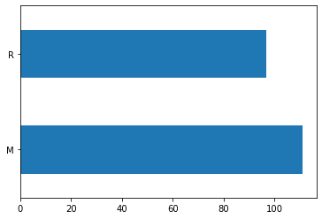

```python
data["Y"].value_counts().plot(kind="barh")
print(data["Y"].value_counts())
```

Efectuemos la partición del set de entrenamiento y del set de prueba a razón 80% y 20%, respectivamente:

```python
y=data.pop("Y")
X=data
X_train, X_test, y_train, y_test = train_test_split(X,y, test_size=.2, random_state=20)
```

```python
tr= tree.DecisionTreeClassifier(criterion="gini", max_depth=20, max_leaf_nodes=30, random_state=20)
trf=tr.fit(X_train,y_train)
```

### Predicción

```python
yp=trf.predict(X_test)
print('Porcentaje de datos bien clasificados: ')
print(accuracy_score(y_test,yp))
```

```
Porcentaje de datos bien clasificados:
0.6428571428571429
```

Notemos que tenemos una precisión de clasificación del 64%, es decir, el porcentaje de datos bien clasificados, positivos o negativos repecto a la variable de respuesta, es 64%.

#### ii) Haga optimización de hiperparámetros, variando los la profundidad del árbol, el máximo número de nodos hojas y el criterio de impureza.

Ahora, efectuemos una optimización de hiperparámetros de este árbol.

```python
param_grid = {
    'criterion':["gini", "entropy"],
    'max_depth': [i for i in range(5,20,1)],
    'max_leaf_nodes': [i for i in range(5,30,1)]
}

model=GridSearchCV(tree.DecisionTreeClassifier(random_state=5),param_grid, scoring="accuracy")
model.fit(X_train,y_train)
```

```
GridSearchCV(estimator=DecisionTreeClassifier(random_state=5),
             param_grid={'criterion': ['gini', 'entropy'],
                         'max_depth': [5, 6, 7, 8, 9, 10, 11, 12, 13, 14, 15,
                                       16, 17, 18, 19],
                         'max_leaf_nodes': [5, 6, 7, 8, 9, 10, 11, 12, 13, 14,
                                            15, 16, 17, 18, 19, 20, 21, 22, 23,
                                            24, 25, 26, 27, 28, 29]},
             scoring='accuracy')
```

```python
print("El accuracy del modelo es:", model.score(X_test,y_test))
print("Hiperparámetros:", str(model.best_params_))
```

```
El accuracy del modelo es: 0.6904761904761905
Hiperparámetros: {'criterion': 'gini', 'max_depth': 5, 'max_leaf_nodes': 7}
```

Con esta optimización de hyperparámetros se consiguió aumentar aproximadamente 5% la precisión del modelo.

#### iii) Haga un análisis costo complejidad y gráfique cpp alpha vs impureza, numero de nodos hoja, y finalmente la gráfica de alpha vs accuracy en la muestra de entrenamiento y de prueba. ¿Qué concluye acerca del valor de cpp alpha?

Efectuemos ahora un análisis de podado costo-complejidad. Primeramente, evaluemos la gráfica de impureza en los nodos terminales vs el valor alpha de podado costo-complejidad.

```python
tr_opt=tree.DecisionTreeClassifier(criterion='gini',max_depth=5,max_leaf_nodes=7)
path=tr.opt=tr_opt.cost_complexity_pruning_path(X_train, y_train)
ccp_alphas, impurezas = path.ccp_alphas, path.impurities
```

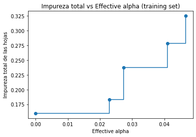

```python
fig, ax= plt.subplots()
ax.plot(ccp_alphas[:-1], impurezas[:-1], marker='o', drawstyle='steps-post')
ax.set_xlabel("Effective alpha")
ax.set_ylabel("Impureza total de las hojas")
ax.set_title("Impureza total vs Effective alpha (training set)")
```

Continuemos con el número de nodos terminales y la profundidad del árbol vs el valor alpha:

```python
arboles=[]
for ccp_alpha in ccp_alphas:
    arbol=tree.DecisionTreeClassifier(random_state=5, ccp_alpha=ccp_alpha)
    arbol.fit(X_train,y_train)
    arboles.append(arbol)

arboles=arboles[:-1]
```

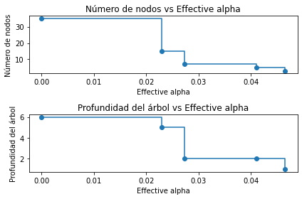

```python
#contado el número de cada arbol para cada ccp_alpha
n_nodos=[arbol.tree_.node_count for arbol in arboles ]

#contabilizando la profundidad de cada árbol
depth=[arbol.tree_.max_depth for arbol in arboles]

#grafiquemos
fig, ax =plt.subplots(2,1)
ax[0].plot(ccp_alphas[:-1], n_nodos, marker='o', drawstyle='steps-post')
ax[0].set_xlabel("Effective alpha")
ax[0].set_ylabel("Número de nodos")
ax[0].set_title("Número de nodos vs Effective alpha")

ax[1].plot(ccp_alphas[:-1], depth, marker='o', drawstyle='steps-post')
ax[1].set_xlabel("Effective alpha")
ax[1].set_ylabel("Profundidad del árbol")
ax[1].set_title("Profundidad del árbol vs Effective alpha")

fig.tight_layout()
```

Finalmente, confeccionemos la gráfica contra el score obtenido al ajustar el modelo al set de entrenamiento y el set de prueba:

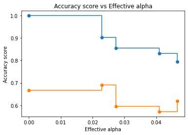

```python
train_sc=[arbol.score(X_train, y_train) for arbol in arboles]
test_sc=[arbol.score(X_test, y_test) for arbol in arboles]

fig, ax=plt.subplots()
ax.plot(ccp_alphas[:-1],train_sc, marker='o', drawstyle='steps-post', label="train")
ax.plot(ccp_alphas[:-1], test_sc, marker='o', drawstyle='steps-post', label="test")
ax.set_xlabel("Effective alpha")
ax.set_ylabel("Accuracy score")
ax.set_title("Accuracy score vs Effective alpha")
```

Por lo tanto, se concluye que, conforme se aumenta el valor de ccp alpha, el nivel de impureza en los nodos aumenta, y el número de nodos y la profunidad disminuyen. Más aún. El valor de ccp alpha que maximiza el score de precisión en el set de test es 0.025. Note que para un valor nulo de ccp alpha, la precisión es del 100% en el set de entrenamiento y de poco menos del 70% para el set de prueba, como se vio anteriormente.

Procedamos a verificar cómo se mejora la precisión del modelo optimizado en sus hyperparámetros con el valor obtenido de ccp alpha:

```python
tr_opt_alpha=tree.DecisionTreeClassifier(max_depth=5,max_leaf_nodes=7, ccp_alpha=0.025, random_state=5)
sc_opt_aplha=tr_opt_alpha.fit(X_train, y_train).score(X_test, y_test)
print("El accuracy del modelo optimizado con ccp alpha es: ", sc_opt_aplha)
```

```
El accuracy del modelo optimizado con ccp alpha es:  0.7142857142857143
```

De esta manera, se obtuvo una mejora del accuracy del modelo optimizado de 69% a 71%.

#### iv) Ajuste un modelo de Random Forest, Bagging y Boosting a los datos de sonar.

```python
from sklearn.ensemble import RandomForestClassifier
```

```python
randomForest = RandomForestClassifier(max_depth=7,n_estimators=100, random_state=20)

rff=randomForest.fit(X_train,y_train)
```

Verifiquemos el porcentaje de datos bien clasificados por este modelo:

```python
yp=rff.predict(X_test)
print('Porcentaje de datos bien clasificados con Random Forest: ')
print(accuracy_score(y_test,yp))
```

```
Porcentaje de datos bien clasificados con Random Forest:
0.7619047619047619
```

Note como la variación mejora respecto al modelo del árbol anterior

```python
from sklearn.ensemble import BaggingClassifier
```

Ajustemos ahora un modelo Bagging para estos datos y veamos el score:

```python
cart=tree.DecisionTreeClassifier(max_depth=7)
n_trees=62
baggingModel=BaggingClassifier(base_estimator=cart,n_estimators=n_trees,random_state=20)
bmf = baggingModel.fit(X_train,y_train)
```

```python
yp=bmf.predict(X_test)
print('Porcentaje de datos bien clasificados con Bagging: ')
print(accuracy_score(y_test,yp))
```

```
Porcentaje de datos bien clasificados con Bagging:
0.6904761904761905
```

```python
from sklearn.ensemble import AdaBoostClassifier
```

```python
n_trees=100

boostingModel = AdaBoostClassifier(base_estimator=cart, n_estimators=n_trees,random_state=20)
abmf = boostingModel.fit(X_train,y_train)
```

```python
yp=abmf.predict(X_test)
print('Porcentaje de datos bien clasificados con Adaboosting: ')
print(accuracy_score(y_test,yp))
```

```
Porcentaje de datos bien clasificados con Adaboosting:
0.6904761904761905
```

v) Obtenga las matrices de confusión y curva ROC.

```
Test results: confusion matrix
[[23  2]
 [ 8  9]]
```

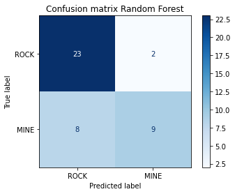

```python
disp = plot_confusion_matrix(rff, X_test, y_test,
                             display_labels=['ROCK','MINE'],
                             cmap=plt.cm.Blues,
                             normalize=None)
disp.ax_.set_title('Confusion matrix Random Forest')

print('Test results: confusion matrix')
print(disp.confusion_matrix)
```

```
Test results: confusion matrix
[[18  7]
 [ 6 11]]
```

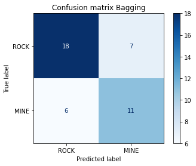

```python
disp = plot_confusion_matrix(bmf, X_test, y_test,
                             display_labels=['ROCK','MINE'],
                             cmap=plt.cm.Blues,
                             normalize=None)
disp.ax_.set_title('Confusion matrix Bagging')

print('Test results: confusion matrix')
print(disp.confusion_matrix)
```

```
Test results: confusion matrix
[[16  9]
 [ 4 13]]
```

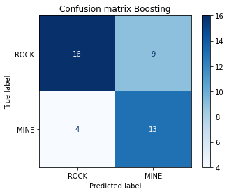

```python
disp = plot_confusion_matrix(abmf, X_test, y_test,
                             display_labels=['ROCK','MINE'],
                             cmap=plt.cm.Blues,
                             normalize=None)
disp.ax_.set_title('Confusion matrix Boosting')

print('Test results: confusion matrix')
print(disp.confusion_matrix)
```

```python
from sklearn.metrics import roc_curve
from sklearn.metrics import roc_auc_score

def plot_roc_curve(fpr, tpr):
    plt.plot(fpr, tpr, color='orange', label='ROC')
    plt.plot([0, 1], [0, 1], color='darkblue', linestyle='--')
    plt.xlabel('False Positive Rate')
    plt.ylabel('True Positive Rate')
    plt.title('Receiver Operating Characteristic (ROC) Curve')
    plt.legend()
    plt.show()
```

Efetuemos el cálculo del AUC para el modelo de Random Forest

```python
X_train, X_test, y_train, y_test = train_test_split(X,y, test_size=.2, random_state=20)
```

```python
randomForest = RandomForestClassifier(max_depth=7,n_estimators=100, random_state=20)

rff=randomForest.fit(X_train,y_train)
```

```python
probs = rff.predict_proba(X_test)
probs = probs[:, 1]
auc = roc_auc_score(y_test, probs)
print('AUC Random Forest: %.2f' % auc)
```

```
AUC Random Forest: 0.85
```

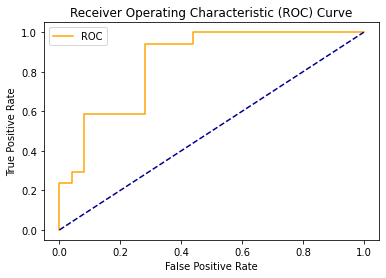

```python
fpr, tpr, thresholds = roc_curve(y_test, probs,pos_label ='R')
plot_roc_curve(fpr, tpr)
```

Análogamente, para el modelo de Bagging y Boosting:

```python
probs = bmf.predict_proba(X_test)

probs = probs[:, 1]

auc = roc_auc_score(y_test, probs)
print('AUC Bagging: %.2f' % auc)
```

```
AUC Bagging: 0.81
```

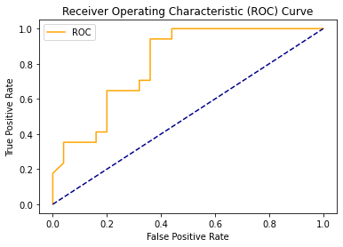

```python
fpr, tpr, thresholds = roc_curve(y_test, probs,pos_label ='R')
plot_roc_curve(fpr, tpr)
```

```python
probs = abmf.predict_proba(X_test)

probs = probs[:, 1]

auc = roc_auc_score(y_test, probs)
print('AUC Boosting: %.2f' % auc)
```

```
AUC Boosting: 0.70
```

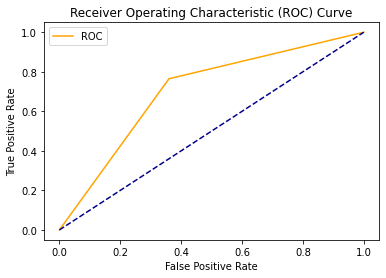

```python
fpr, tpr, thresholds = roc_curve(y_test, probs,pos_label ='R')
plot_roc_curve(fpr, tpr)
```

Finalmente, se calcula el AUC para el modelo del árbol:

```python
probs = tr_opt_alpha.predict_proba(X_test)

probs = probs[:, 1]

auc = roc_auc_score(y_test, probs)
print('AUC Decision Tree: %.2f' % auc)
```

```
AUC Decision Tree: 0.66
```

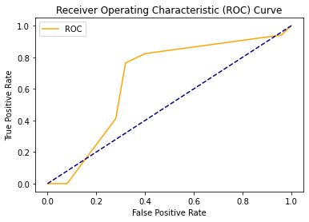

```python
fpr, tpr, thresholds = roc_curve(y_test, probs,pos_label ='R')
plot_roc_curve(fpr, tpr)
```

Por lo tanto, el modelo ajustado de Random Forest es el que tiene el AUC más alto respecto a los demás modelos con un valor de 0.85.